# 文件去哪儿了

黑箱、黑箱、无数的黑箱

it

thinking

总会新问题，人生的意义在不不搞懂什么😄

作者

Adopapa

日期

2024/12/09,第50周

Modified

2024/12/09,第50周

Keywords

quarto, installation, finder, 黑箱

## 问题来了：安装完成版本未变

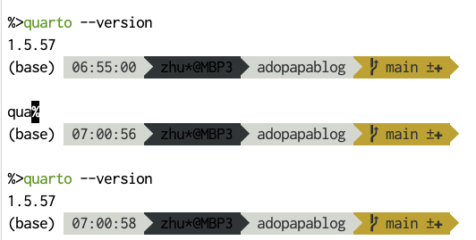

过来一下刚才的安装过程，以前选择的都是为这个电脑的所有用反转用，其实自己就是这台电脑的唯一用户，所以选择了仅为自己安全这句话平时装的不同之处吧。

[figure not shown]

在AI求证一下如何？

**问题**

quarto安装前版本1.5.57， 在quarto下载安装1.6.39后，quarto —version显示的版本仍然是1.5.57.。之 前的quarto安装，我选择了 为这台电脑上的所有用户安装，本次安装选择仅为我安装，这是问题所在吗？

## AI的回复

是的！这 个问题很可能是由于你之前选择“**为这台电脑上的所有用户安装**”，而此次安装选择了“**仅为我安装**”。两 种安装方式会导致 Quarto 被安装到不同的路径，并且系统的 **PATH 环境变量** 仍然指向旧版本的 Quarto，可执行文件的位置优先级没有更新，从而导致新版本的 Quarto 没有被正确应用。

### **理解问题的原因**

1. **为所有用户安装**
   - 如果之前安装时选择了“为所有用户安装”，Quarto 通常会安装到系统范围的路径中，例如：
     - Windows: `C:\Program Files\Quarto\bin\quarto.exe`
     - macOS/Linux: `/usr/local/bin/quarto`
   - 系统环境变量（PATH）会被更新，使系统始终可以找到这路径的 Quarto。
2. **仅为我安装**
   - 如果本次安装选择 “仅为我安装”，Quarto 可能会安装到用户级别的路径中，例如：
     - Windows: `%LOCALAPPDATA%\Programs\Quarto\bin\quarto.exe`
     - macOS/Linux: `~/.local/bin/quarto （没有这个目录）`
   - 用户级别的安装不会覆盖系统范围内的 `PATH` 路径，导致仍然调用旧版 Quarto。

   **因此，系统仍然找到的是之前为所有用户安装的旧版本 `quarto`，而不是你刚刚安装的新版本。**

### **解决方法**

option 1: 重新全局安装，删除只为我安装的版本 （我的选择）

option 2: 将只为我安装的版本加入PATH变量。。。

## 新问题：如何删除只为我安装的版本

### **定位文件的几个方案**

```bash
#|label: findfile
whereis quarto
# quarto: /usr/local/bin/quarto

which quarto
#/usr/local/bin/quarto
# 这两个命令器只显示为所有人安装的路径，不显示只为我安装的路径

find ~ -name "quarto" 2>/dev/null

# ～/Library/Application Support/quarto
# ~/Library/Application Support/quarto
#
# ~/Library/Caches/deno/gen/file/Applications/quarto
# ~/Library/Caches/quarto
# ~/Applications/quarto
# ~/Applications/quarto/bin/quarto
# ~/Applications/quarto/share/formats/typst/pandoc/quarto
# ~/Applications/quarto/share/lua-types/quarto
# ~/Applications/quarto/share/extensions/quarto
# ~/Documents/writer/adopapablog/posts/quarto
# ~/Documents/writer/adopapablog/www/posts/quarto
# ~/Documents/writer/adopapablog/_freeze/posts/quarto
# ~/Documents/writer/adopapablog/.quarto/idx/posts/quarto
# ~/Documents/writer/adopapablog/.quarto/_freeze/posts/quarto
# ~/Documents/coder/rlang/quarto
# 跳出了一个文件就卡在哪里了，我另外开了窗口使用其它命名.
# 2024-12-09 07:43:39 终于结束了查找，结果可比locate 简洁了，确实也太慢了。

locate quarto
# .....
# /Applications/quarto
# /Applications/quarto/bin
# /Applications/quarto/bin/quarto
# /Applications/quarto/bin/quarto.js
# /Applications/quarto/bin/tools
# /Applications/quarto/bin/tools/aarch64
# .....
# 返回也太多了啊哈，确实强大
```

折腾到最后发现其实应该先到Application里面去看一下了，所以这是个问题，搜索源用多了传统的方法却丢掉很多，这不于邯郸学步了，这个要警惕，虽然是个小问题则是我们在这个变化中的患得患失。

finder里直接删除了/Applications/quarto,出问题了

```bash
#|label: checkafterdelete
quarto --version
# zsh: command not found: quarto --version
# 看来pkg是安装到application，然后关联到/usr/local/bin/quarto
```

找回垃圾堆里的安装文件，重新安装pkg

```bash
#|label: checkaftinstl
#|eval: false
quarto --version
#1.6.39
```

### **总结**

通过文件到哪里去了？通 过寻找文件的过程，你会发现习惯依赖的微小变动也会导致的很多的麻烦。不 要说AI, 就是一片普通的电脑，对我们来说真的是一个巨大的黑箱.人类从来都是在黑箱的下前形的谁又真正搞懂了火呢？

就是一个折腾，如果一开始你就选择默认的按钮，哪有这一个多小时的折腾呢？